# Leave-one-out test

fd

2025-02-22

```r
library(tidyverse)
library(metafor)
library(devtools)
load_all() # Load dev package
```

### Example with Eklof data

```r
data(eklof)

# Calculate the effect size
eklof <- escalc(measure = "ROM",
                n1i = N_control,
                sd1i = SD_control,
                m1i = mean_control,
                n2i = N_treatment,
                sd2i = SD_treatment,
                m2i = mean_treatment,
                var.names = c("lnRR", "vlnRR"),
                data = eklof)

# Add the observation level factor
eklof$Datapoint <- as.factor(seq(1, dim(eklof)[1], 1))

# Also, we can get the sample size, which we can use for weighting if we would like
eklof$N <- rowSums(eklof[, c("N_control", "N_treatment")])
```

Create **Authors** column with first author and year, to make it pretty

```r
eklof <- eklof %>%
  mutate(Author = paste(First.author, Publication.year, sep = ", "))
```

```r
# fit a meta-regression with the intercept (contrast)
eklof_MR0 <- rma.mv(yi = lnRR,
                    V = vlnRR,
                    mods = ~Grazer.type,
                    random = list(~1 | ExptID,
                                  ~1 | Datapoint),
                    data = eklof)

results <- mod_results(eklof_MR0, group = "Author")
results
```

[output not shown]

## leave-one-out plot

Accepts all the arguments from orchard_plot()

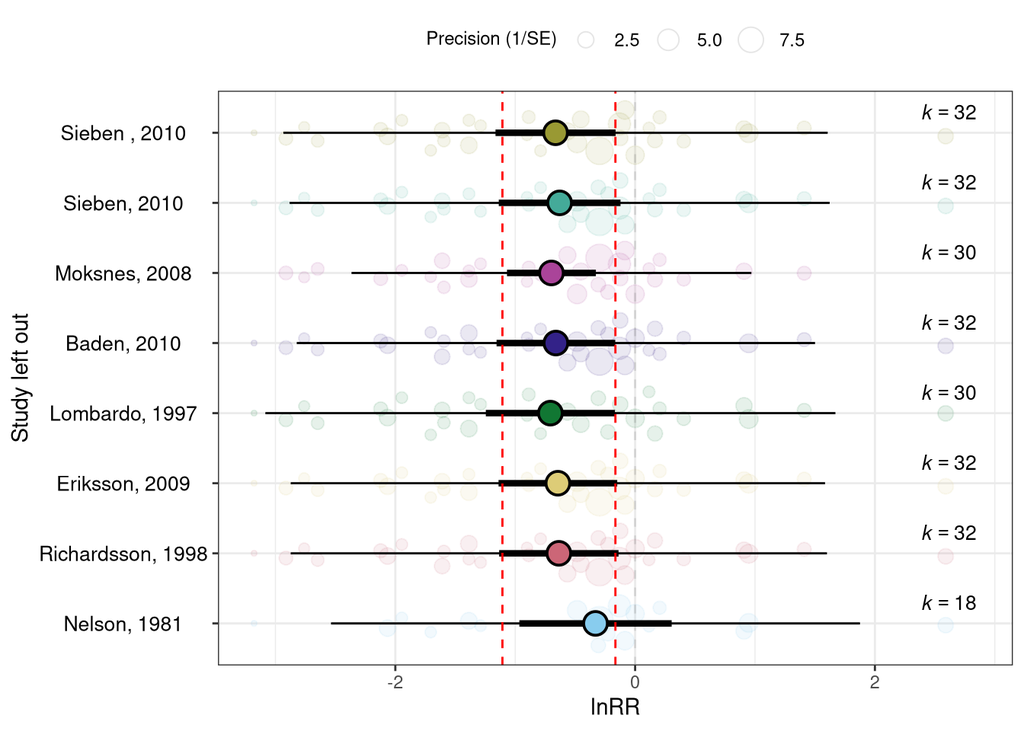

```r
orchard_leave1out(eklof_MR0,
                  group = "Author",
                  xlab = "lnRR",
                  ylab = "Study left out",
                  trunk.size = 1.2,
                  branch.size = 1.5,
                  legend.pos = "top.out")
```

## Example with BCG vaccine data from metafor

```r
dat <- metafor::escalc(measure = "RR", ai = tpos, bi = tneg, ci = cpos, di = cneg, data = dat.bcg)

dat <- dat %>%
  mutate(reference = paste(author, year, sep = ", "))

res <- metafor::rma(yi, vi, data = dat)
```

Add a lot of arguments just to see if they work

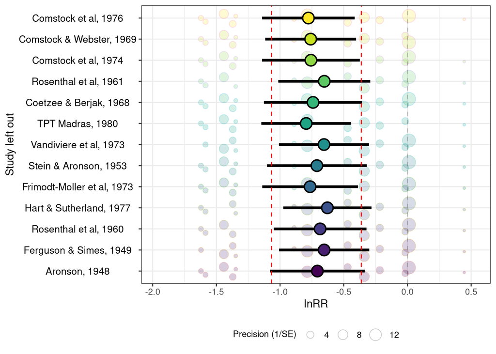

```r
orchard_leave1out(res,
                  group = "reference",
                  xlab = "lnRR",
                  ylab = "Study left out",
                  legend.pos = "bottom.out",
                  trunk.size = 1.2,
                  branch.size = 1.3,
                  twig.size = 0,
                  k.pos = "none",
                  alpha = 0.2,
                  cb = FALSE) +
  scale_fill_viridis_d()
```

## Function leave_one_out()

The function leave_one_out() returns the results, imitating the output from mod_results(). It could be useful if someone wants to use the results for something else.

```r
res_loo <- leave_one_out(res, group = "reference")
res_loo
```

```
##                          name   estimate    lowerCL    upperCL   lowerPR
## 1               Aronson, 1948 -0.7070838 -1.0794010 -0.3347666 -1.902891
## 2      Ferguson & Simes, 1949 -0.6540312 -1.0081881 -0.2998743 -1.771786
## 3       Rosenthal et al, 1960 -0.6855544 -1.0495324 -0.3215765 -1.853709
## 4     Hart & Sutherland, 1977 -0.6284094 -0.9745766 -0.2822422 -1.691052
## 5  Frimodt-Moller et al, 1973 -0.7641701 -1.1400674 -0.3882728 -1.947616
## 6       Stein & Aronson, 1953 -0.7108766 -1.1033678 -0.3183853 -1.949935
## 7      Vandiviere et al, 1973 -0.6552476 -1.0089693 -0.3015259 -1.773625
## 8            TPT Madras, 1980 -0.7947676 -1.1473219 -0.4422133 -1.878150
## 9      Coetzee & Berjak, 1968 -0.7411973 -1.1266735 -0.3557211 -1.962263
## 10      Rosenthal et al, 1961 -0.6530329 -1.0141910 -0.2918748 -1.783509
## 11       Comstock et al, 1974 -0.7578586 -1.1415943 -0.3741230 -1.964187
## 12   Comstock & Webster, 1969 -0.7598121 -1.1167043 -0.4029199 -1.904874
## 13       Comstock et al, 1976 -0.7775362 -1.1411804 -0.4138919 -1.917281
##      upperPR
## 1  0.4887237
## 2  0.4637236
## 3  0.4826001
## 4  0.4342333
## 5  0.4192760
## 6  0.5281817
## 7  0.4631301
## 8  0.2886153
## 9  0.4798681
## 10 0.4774432
## 11 0.4484696
## 12 0.3852500
## 13 0.3622090
```

For comparison, this is the output from metafor’s leave1out:

```r
metafor::leave1out(res)
```

```
##
##     estimate     se    zval   pval   ci.lb   ci.ub        Q     Qp   tau2
## -1   -0.7071 0.1900 -3.7223 0.0002 -1.0794 -0.3348 151.5826 0.0000 0.3362
## -2   -0.6540 0.1807 -3.6195 0.0003 -1.0082 -0.2999 145.3176 0.0000 0.2926
## -3   -0.6856 0.1857 -3.6916 0.0002 -1.0495 -0.3216 150.1970 0.0000 0.3207
## -4   -0.6284 0.1766 -3.5580 0.0004 -0.9746 -0.2822  96.5626 0.0000 0.2628
## -5   -0.7642 0.1918 -3.9845 0.0001 -1.1401 -0.3883 151.3200 0.0000 0.3278
## -6   -0.7109 0.2003 -3.5499 0.0004 -1.1034 -0.3184 128.1867 0.0000 0.3596
## -7   -0.6552 0.1805 -3.6307 0.0003 -1.0090 -0.3015 145.8296 0.0000 0.2930
## -8   -0.7948 0.1799 -4.4184 0.0000 -1.1473 -0.4422  67.9858 0.0000 0.2732
## -9   -0.7412 0.1967 -3.7686 0.0002 -1.1267 -0.3557 152.2051 0.0000 0.3495
## -10  -0.6530 0.1843 -3.5439 0.0004 -1.0142 -0.2919 139.8271 0.0000 0.2987
## -11  -0.7579 0.1958 -3.8708 0.0001 -1.1416 -0.3741 151.4655 0.0000 0.3405
## -12  -0.7598 0.1821 -4.1727 0.0000 -1.1167 -0.4029 150.7868 0.0000 0.3082
## -13  -0.7775 0.1855 -4.1908 0.0000 -1.1412 -0.4139 149.7884 0.0000 0.3037
##          I2      H2
## -1  93.2259 14.7622
## -2  92.2540 12.9098
## -3  92.9354 14.1551
## -4  90.4125 10.4302
## -5  92.7634 13.8187
## -6  90.9118 11.0033
## -7  92.2777 12.9495
## -8  87.0314  7.7109
## -9  93.2133 14.7346
## -10 92.2322 12.8737
## -11 91.8110 12.2114
## -12 92.6782 13.6579
## -13 92.3444 13.0623
```

The results from leave_one_out() can be used for custom ggplot2 plots, for example:

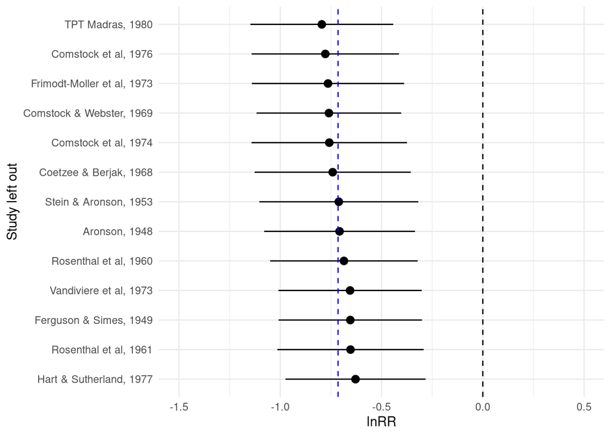

```r
res_loo$mod_table %>%
  ggplot(aes(x = reorder(name, -estimate),
             y = estimate,
             ymin = lowerCL,
             ymax = upperCL)) +
  geom_pointrange() +
  coord_flip() +
  geom_hline(yintercept = res$beta, linetype = 2, color = "blue") +
  geom_hline(yintercept = 0, linetype = 2, color = "black") +
  xlab("Study left out") +
  ylab("lnRR") +
  ylim(-1.5, 0.5) +
  theme_minimal()
```

## To-do

- **orchard_plot()**: There are only 20 colors, but they are not recycled. This is a problem when there are more than 20 studies (or whatever group is used)
- Transformation is not working yet. This is because the transformation is handled inside orchard_plot() and the lines for 95% CI are added on top of the orchard plot. Maybe move the transformation out of orchard_plot() to a separate function?
- Only works for intercepts, No mod, no ‘by’ argument. Fix this
- Make inner lines optional
- Add some arguments to modify the 95% confidence lines and also add the overall estimate